### Sedi territoriali di Bergamo e Sondrio : analisi del carico di lavoro in FTE del personale di comparto nel 2019

#### Fonte dati

Di seguito è riportata un’analisi del carico di lavoro svolto nel 2019 presso i laboratori della struttura complessa BG-SO-VA dal personale di comparto, utilizzando i dati di attività e di ore lavorate estratte dalle seguenti fonti:

- Dati di attività : Business Object
- Dati ore lavorate : registrazioni delle presenze/mese in minuti (convertiti in ore settimana) ottenuti mediante il software SIGMA. I dati fanno riferimento alle ore effettivamente lavorate,registrate giornalmente nelle varie sedi, comprensive di missioni e d aggregati per mese.

#### Metodologia

**L’unità laboratorio/tempo** rappresenta la più piccola unità di aggregazione dei dati, dove la componente temporale può essere espressa in giorni/sett/ mesi/anno a seconda delle esigenze. Il **numero di esami eseguiti** per unità di aggregazione rappresenta l’indicatore di attività del laboratorio. Il **numero di conferimenti per reparto accettante** rappresenta l’indicatore dell’attività di accettazione.

I dati riferiti agli esami conferiti presso la struttura complessa ma eseguiti presso altri reparti dell’Istituto (Altri laboratori), sono stati presi in considerazione esclusivamente in riferimento all’attività di accettazione, preparazione e trasferimento dei campioni.

Nelle diverse strutture il personale tecnico, sulla base delle competenze e qualificazioni viene assegnato ai diversi laboratori in proporzioni al tempo di lavoro indicato dai responsabili di struttura. Le ore lavorate sono state quindi ripartite nelle medesime proporzioni per ogni collaboratore nei diversi laboratori e nei diversi mesi dell’anno.

L’analisi è stata condotta per la sede territoriale di BG e di SO per i quali erano disponibili i dati relativi alla distribuzione del personale nei diversi laboratori.

E’ stato utilizzato come **tempo standard di lavoro** quello previsto dal contratto per il personale di comparto di **36 h settimanali** per un totale di **48 settimane/anno** , pari a **1728 h a persona/anno**. Il numero di 48 settimane si ottiene per convenzione sottraendo al numero di settimane in un anno (52), il numero medio di giorni di ferie previsto dai contratti (per lavoratori su 5 giorni) pari a 28gg equivalente a 4 settimane: 52-4= 48. Per il personale part-time si è proceduto a conteggiare le ore/settimana previste dal contratto in essere. Le modalità di definizione del numero di settimane lavorative determina è fonte di approssimazione più o meno elevata degli indicatori di seguito utilizzati.

#### Full Time Equivalent (FTE)

Per ogni unità di aggregazione si è proceduto quindi a calcolare il FTE mediante la formula:

$$\text{FTE}_{u} = \frac{\text{numero ore erogate}_{u}}{\text{numero di ore standard}_{u} }$$

#### Dati di attività

Nella sezione di Sondrio sono stati registrati **34529 conferimenti**, da cui sono stati effettuati **108183** esami in sezione e **22326** presso altri laboratori.

In tabella è riportata per le due sezioni, la distribuzione del n. di conferimenti ed esami effettuati nei differenti laboratori.

| Reparto | laboratorio | Totale conferimenti | Totale esami |
| --- | --- | --- | --- |
| Sede Territoriale di Bergamo | Accettazione | 36737 |  |
| Sede Territoriale di Sondrio | Accettazione | 34529 |  |
| Sede Territoriale di Bergamo | Laboratorio Sierologia |  | 148156 |
|  | Laboratorio Diagnostica Generale |  | 44639 |
|  | Laboratorio Microbiologia degli Alimenti |  | 9695 |
| Sede Territoriale di Sondrio | Laboratorio Sierologia |  | 86210 |
|  | Laboratorio Diagnostica Generale |  | 12552 |
|  | Laboratorio Microbiologia degli Alimenti |  | 9439 |

#### Carichi di lavoro in FTE

La seguente tabella riporta la distribuzione percentuale dell’impiego del personale di comparto nei diversi laboratori. Per ogni matricola sono riportate le ore settimanali da contratto (hsett) e le ore totali (htot) per 48 settimane lavorative.

| reparto | Matricola | hsett | htot | Laboratorio Sierologia | Laboratorio Microbiologia degli Alimenti | Laboratorio Diagnostica Generale | Amministrazione | Accettazione |
| --- | --- | --- | --- | --- | --- | --- | --- | --- |
| Sede Territoriale di Bergamo | 866 | 25 | 1200 | 95 | 0 | 5 | 0 | 0 |
|  | 1523 | 36 | 1728 | 0 | 100 | 0 | 0 | 0 |
|  | 634 | 36 | 1728 | 0 | 0 | 0 | 0 | 100 |
|  | 1046 | 36 | 1728 | 0 | 0 | 100 | 0 | 0 |
|  | 668 | 36 | 1728 | 90 | 0 | 10 | 0 | 0 |
|  | 1797 | 36 | 1728 | 0 | 100 | 0 | 0 | 0 |
|  | 1878 | 36 | 1728 | 0 | 0 | 0 | 0 | 100 |
|  | 1557 | 36 | 1728 | 0 | 0 | 100 | 0 | 0 |
|  | 1877 | 36 | 1728 | 0 | 0 | 0 | 90 | 10 |
| Sede Territoriale di Sondrio | 313 | 36 | 1728 | 25 | 50 | 25 | 0 | 0 |
|  | 629 | 36 | 1728 | 75 | 0 | 25 | 0 | 0 |
|  | 633 | 36 | 1728 | 0 | 5 | 20 | 0 | 75 |
|  | 735 | 36 | 1728 | 0 | 20 | 80 | 0 | 0 |
|  | 974 | 36 | 1728 | 15 | 80 | 5 | 0 | 0 |
|  | 927 | 36 | 1728 | 0 | 0 | 0 | 60 | 40 |

Sulla base di questa ripartizione percentuale dell’impegno nei diversi laboratori si calcola l’impegno orario previsto per matricola. La somma per laboratorio dei diversi impegni orari definisce la disponibilità (da contratto) di ore lavorative nei differenti laboratori, per le esecuzione delle attività specifiche.

Nelle seguenti tabelle distinte per reparto sono riportati gli impegni orari per maricola e il dato complessivo per laboratorio

distribuzione dipsonibilità ore da contratto suddivise per matricola/laboratorio della sezione di Bergamo

Matricola

hsett

htot

Laboratorio Sierologia

Laboratorio Microbiologia degli Alimenti

Laboratorio Diagnostica Generale

Amministrazione

Accettazione

866

25

1200

1140.0

0

60.0

0.0

0.0

1523

36

1728

0.0

1728

0.0

0.0

0.0

634

36

1728

0.0

0

0.0

0.0

1728.0

1046

36

1728

0.0

0

1728.0

0.0

0.0

668

36

1728

1555.2

0

172.8

0.0

0.0

1797

36

1728

0.0

1728

0.0

0.0

0.0

1878

36

1728

0.0

0

0.0

0.0

1728.0

1557

36

1728

0.0

0

1728.0

0.0

0.0

1877

36

1728

0.0

0

0.0

1555.2

172.8

Total

15024

2695.2

3456

3688.8

1555.2

3628.8

distribuzione disponibilità ore da contratto suddivise per matricola/laboratorio della sezione di Sondrio

Matricola

hsett

htot

Laboratorio Sierologia

Laboratorio Microbiologia degli Alimenti

Laboratorio Diagnostica Generale

Amministrazione

Accettazione

313

36

1728

432.0

864.0

432.0

0.0

0.0

629

36

1728

1296.0

0.0

432.0

0.0

0.0

633

36

1728

0.0

86.4

345.6

0.0

1296.0

735

36

1728

0.0

345.6

1382.4

0.0

0.0

974

36

1728

259.2

1382.4

86.4

0.0

0.0

927

36

1728

0.0

0.0

0.0

1036.8

691.2

Total

10368

1987.2

2678.4

2678.4

1036.8

1987.2

Da cui si ricava, per ogni laboratorio, le risorse disponibili e le risorse effettivamente impiegate espresse in FTE per l’attività del 2019:

| reparto | laboratorio | tempo-standard | tempo-lavorato | %tempo-stand utilizzato | FTE-disponibile | FTE-effettivo |
| --- | --- | --- | --- | --- | --- | --- |
| Sede Territoriale di Bergamo | Accettazione | 3629 | 2873 | 79 | 2.1 | 1.66 |
|  | Amministrazione | 1555 | 1207 | 78 | 0.9 | 0.70 |
|  | Laboratorio Diagnostica Generale | 3689 | 3471 | 94 | 2.1 | 2.01 |
|  | Laboratorio Microbiologia degli Alimenti | 3456 | 2792 | 81 | 2.0 | 1.62 |
|  | Laboratorio Sierologia | 2695 | 2385 | 88 | 1.6 | 1.38 |
| Sede Territoriale di Sondrio | Accettazione | 1987 | 1591 | 80 | 1.1 | 0.92 |
|  | Amministrazione | 1037 | 950 | 92 | 0.6 | 0.55 |
|  | Laboratorio Diagnostica Generale | 2678 | 2120 | 79 | 1.6 | 1.23 |
|  | Laboratorio Microbiologia degli Alimenti | 2678 | 2287 | 85 | 1.6 | 1.32 |
|  | Laboratorio Sierologia | 1987 | 1748 | 88 | 1.1 | 1.01 |

Di seguito è riportato in grafico l’andamento mensile dei valori di FTE previsto ed effettivo per i diversi reparti e laboratori.

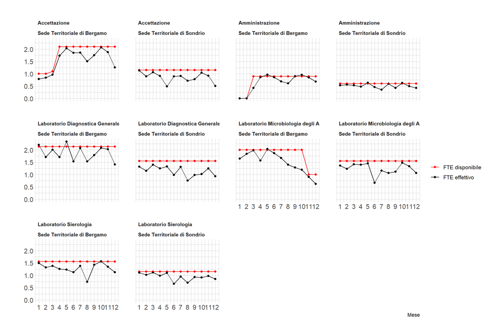

### Attività e FTE

Nella seguente tabella per ogni laboratorio sono riportati i FTE e l’attività eseguita nell’arco del 2019

| Reparto | laboratorio | tempo-standard | tempo-lavorato | %tempo-stand utilizzato | FTE-previsto | FTE-effettivo | Totale conferimenti | Totale esami |
| --- | --- | --- | --- | --- | --- | --- | --- | --- |
| Sede Territoriale di Bergamo | Accettazione | 3629 | 2873 | 79 | 2.1 | 1.66 | 36737 |  |
|  | Laboratorio Diagnostica Generale | 3689 | 3471 | 94 | 2.1 | 2.01 |  | 44639 |
|  | Laboratorio Microbiologia degli Alimenti | 3456 | 2792 | 81 | 2.0 | 1.62 |  | 9695 |
|  | Laboratorio Sierologia | 2695 | 2385 | 88 | 1.6 | 1.38 |  | 148156 |
| Sede Territoriale di Sondrio | Accettazione | 1987 | 1591 | 80 | 1.1 | 0.92 | 34529 |  |
|  | Laboratorio Diagnostica Generale | 2678 | 2120 | 79 | 1.6 | 1.23 |  | 12552 |
|  | Laboratorio Microbiologia degli Alimenti | 2678 | 2287 | 85 | 1.6 | 1.32 |  | 9439 |
|  | Laboratorio Sierologia | 1987 | 1748 | 88 | 1.1 | 1.01 |  | 86210 |